# Homework 3

Luo Bingjun 2017013573 Software 71

2019/4/12

# Chapter 5

```r
data=read.table("T5-1.DAT")
n = dim(data)[1]
p = dim(data)[2]
colnames(data) <- c("X1","X2","X3")
attach(data)
```

Q-Q plot:

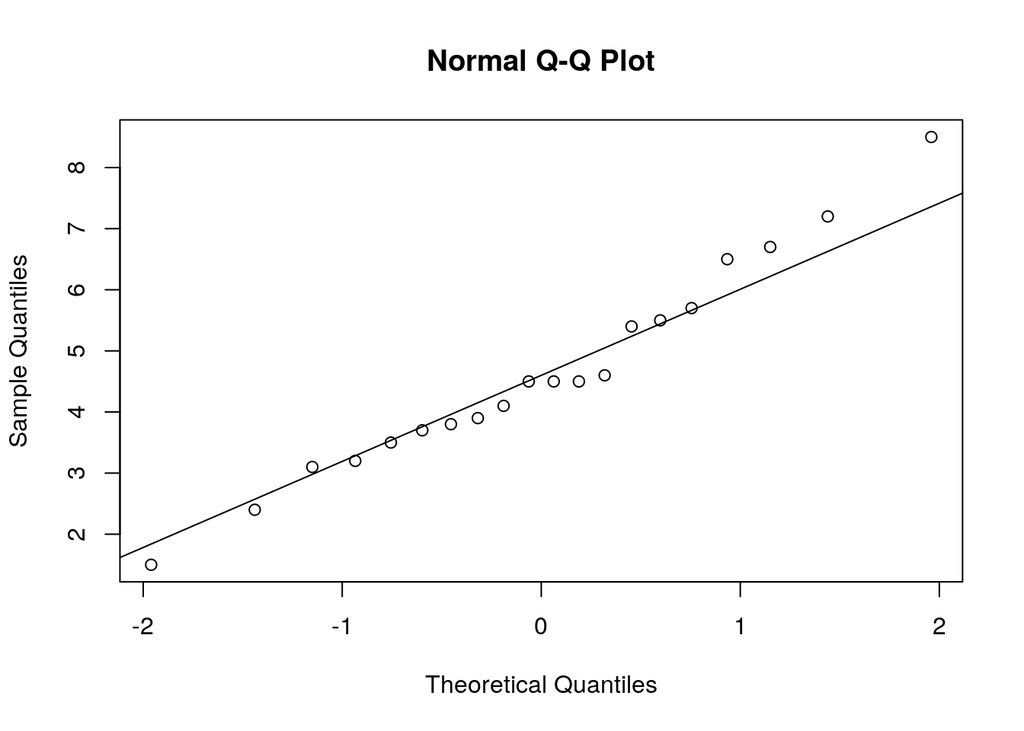

```r
qqnorm(X1)
qqline(X1)
```

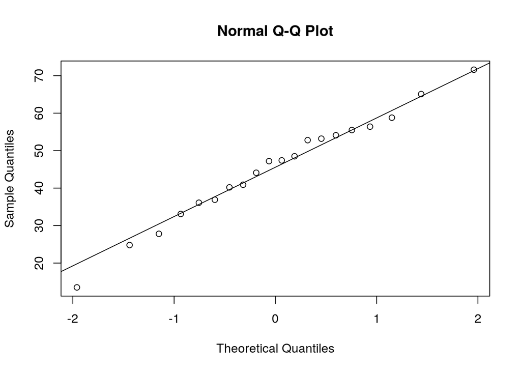

```r
qqnorm(X2)
qqline(X2)
```

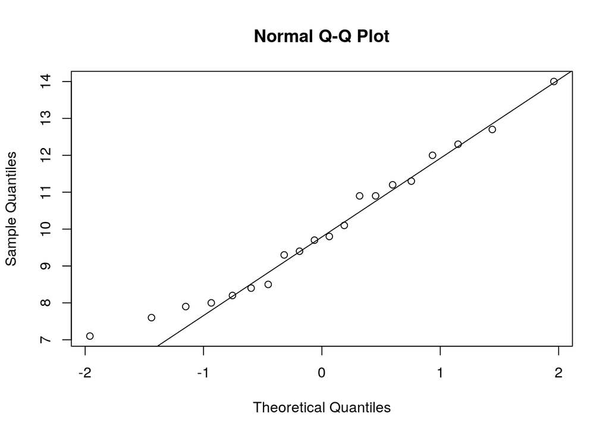

```r
qqnorm(X3)
qqline(X3)
```

scatter plot matrix:

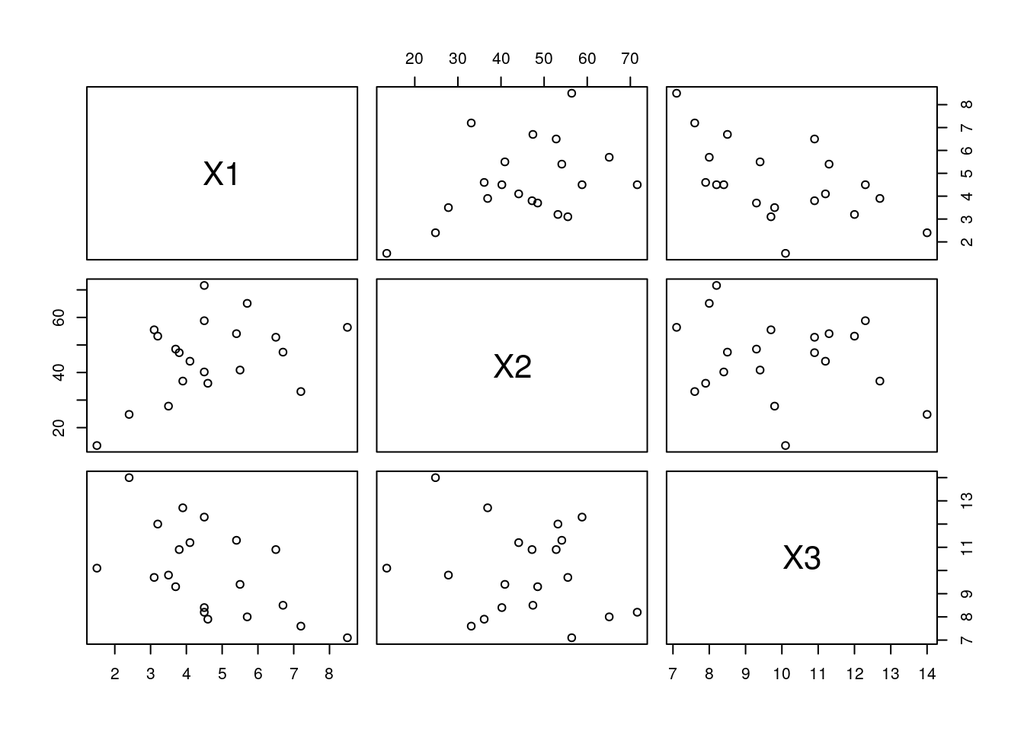

```r
plot(data)
```

Chi-square plot:

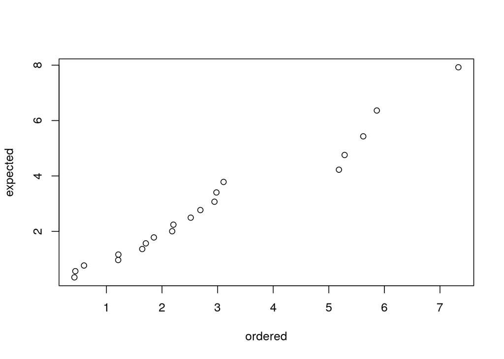

```r
X=as.matrix(data)
d2=c()
for (i in 1:20){
  d2<-c(d2, t(matrix(X[i,]-colMeans(X)))%*%solve(cov(X))%*%(X[i,]-colMeans(X)))
}
# ordered values
ordered <- sort(d2)
# expected values
expected <- qchisq(rank(ordered)/(length(ordered) + 1),p)
plot(ordered, expected)
```

Since there is a relatively strong linear ralationship in Q-Q plot and Chi-square plot, and the variables seems independent from each other, the multivariate normal assumption seems justified.

# Chapter 6

## 1.

a situation fit for paired comparisons:

- the data of two samples shares a one to one correspondence, and the corresponded data has the same variables.
- the same variable of one sample is independent from each other.

a situation not fit for paired comparisons: - the data of the two samples is not one-to-one corresponded. - the same variable of one sample may be not independent.

## 2.

### a.

$$H_0:\mu_1=\mu_2\leftrightarrow H_1:\mu_1\ne\mu_2$$

```r
n1 = 45
n2 = 55
p=2
alpha = 0.05
X1 = matrix(c(204.4,556.6), nrow = p)
X2 = matrix(c(130.0,355.0), nrow = p)
S1 = matrix(c(13825.3,23823.4,23823.4,73107.4), nrow=p)
S2 = matrix(c(8632.0,19616.7,19616.7,55964.5), nrow=p)
Sp = (n1-1)/(n1+n2-2)*S1+(n2-1)/(n1+n2-2)*S2 # S_pooled
T2 = 1/(1/n1+1/n2)*t(X1-X2) %*% solve(Sp) %*% (X1-X2)
# test statistic
F=(n1+n2-p-1)/(p*(n1+n2-2))*T2
F
```

```
##          [,1]
## [1,] 7.951139
```

```r
df(1-alpha,p,n1+n2-p-1)
```

```
## [1] 0.382811
```

Since $F>F_{p,n_1+n_2-p-1}(\alpha)$, we conclude $H_1$, that $\mu_1\ne\mu_2$.

### b.

```r
S = S1/n1+S2/n2
# test statistic
T2 = t(X1-X2) %*% solve(S) %*% (X1-X2) # H0: \mu1-\mu2=0
T2
```

```
##          [,1]
## [1,] 15.65853
```

```r
qchisq(1-alpha,p)
```

```
## [1] 5.991465
```

Since $T^2>\chi_p^2(\alpha)$, we conclude $H_1$, that $\mu_1\ne\mu_2$.

### c.

$$H_1:\Sigma_1=\Sigma_2\leftrightarrow H_1:\Sigma_1\ne\Sigma_2$$

```r
Sp = (n1-1)/(n1+n2-2)*S1+(n2-1)/(n1+n2-2)*S2 # S_pooled
u = (2*p^2+3*p-1)/(6*(p+1)*(2-1))*(1/(n1-1)+1/(n2-1)-1/(n1+n2-2))
# test statistic
C = (1-u)*((n1+n2-2)*log(det(Sp))-(n1-1)*log(det(S1))-(n2-1)*log(det(S2)))
C
```

```
## [1] 18.93306
```

```r
v=1/2*p*(p+1)
qchisq(1-alpha,v)
```

```
## [1] 7.814728
```

Since $C>\chi_v^2(\alpha)$, we conclude $H_1$, that $\Sigma_1\ne\Sigma_2$, to reject the equal variance matrix assumption.

### d.

Prefer (b), because it doesn’t require the equal variance matrix assumption.

## 3: 6.9

### a.

$$d_j=(x_{j,1}-x_{j,p+1},\cdots,x_{j,p}-x_{j,2p})=Cx_j$$

### b.

$$\bar{d}=\frac{1}{n}\sum_{j=1}^nd_j=\frac{1}{n}\sum_{j=1}^nCx_j=C\frac{1}{n}\sum_{j=1}^nx_j=C\bar{x}$$

### c.

$$S_d=\frac{1}{n-1}\sum_{j=1}^n(d_j-\bar{d})(d_j-\bar{d})'=C\frac{1}{n-1}\sum_{j=1}^n(x_j-\bar{x})(x_j-\bar{x})'C'=CSC'$$
## 4: 6.11